# Summary_of_Results

Bonni Beaupied and Sheena Martenies

7/22/2019

## Distributions of outcome and predictor variables

Below are the histograms, scatter plots, and autocorrelation plots for the outcomes and predictor variables included in the dataset.

#### Average milk production (L) per day

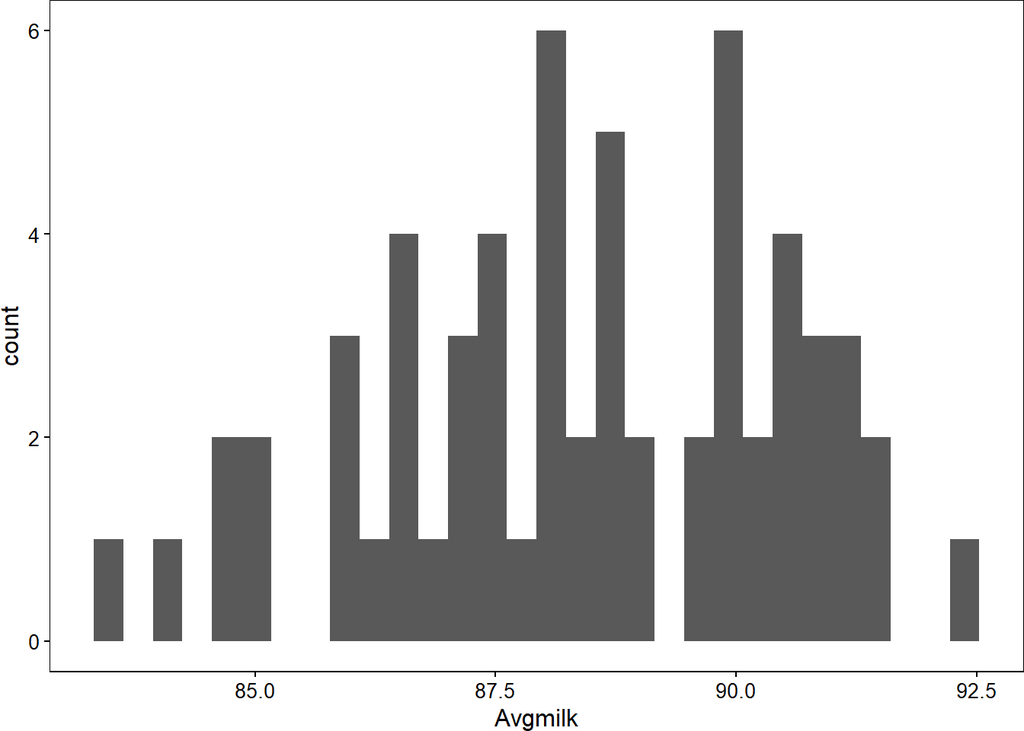

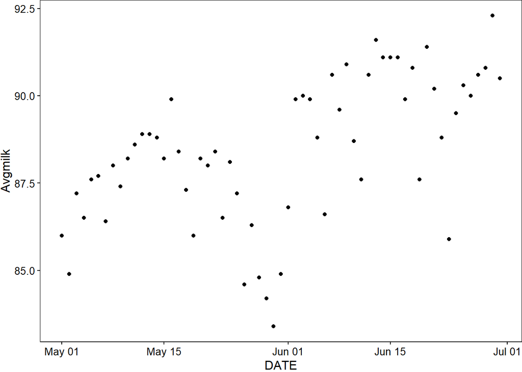

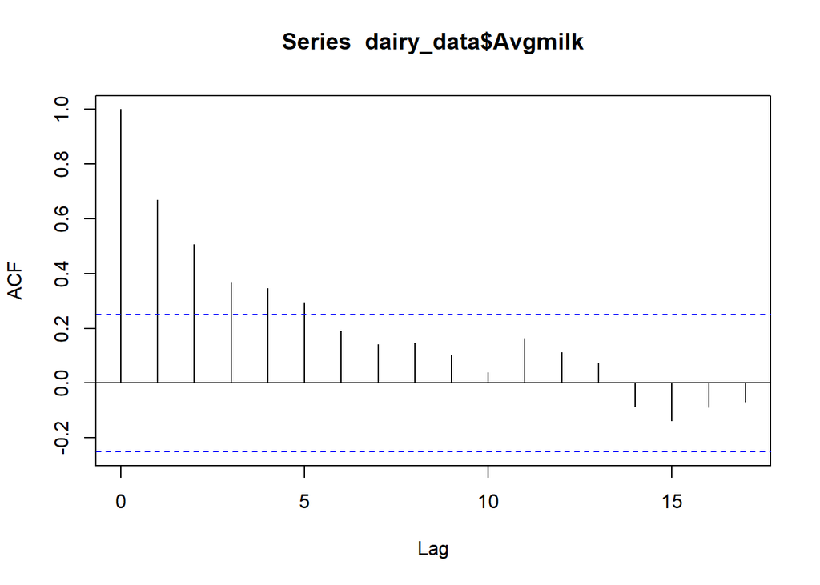

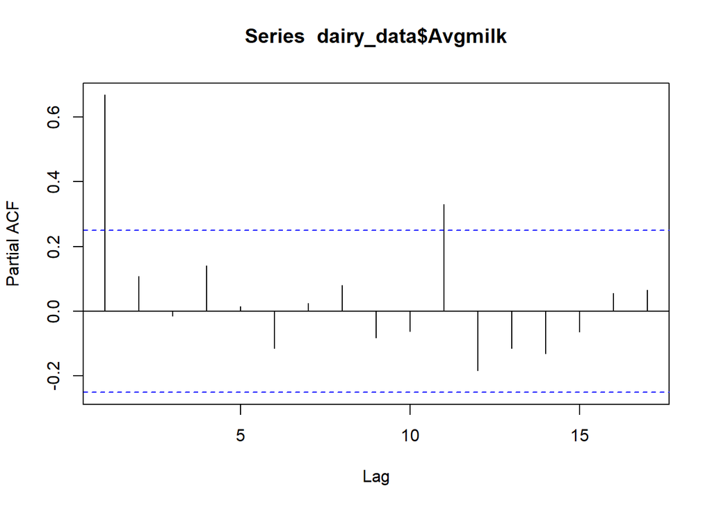

#### Somatic Cell Counts

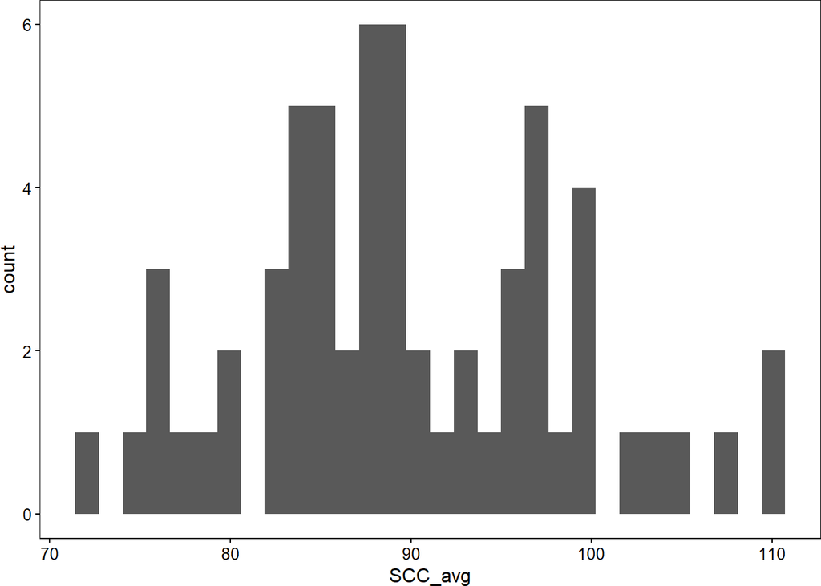

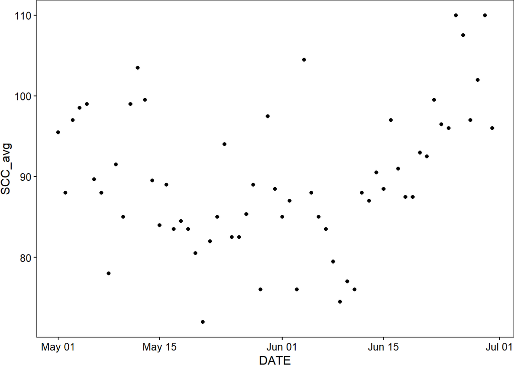

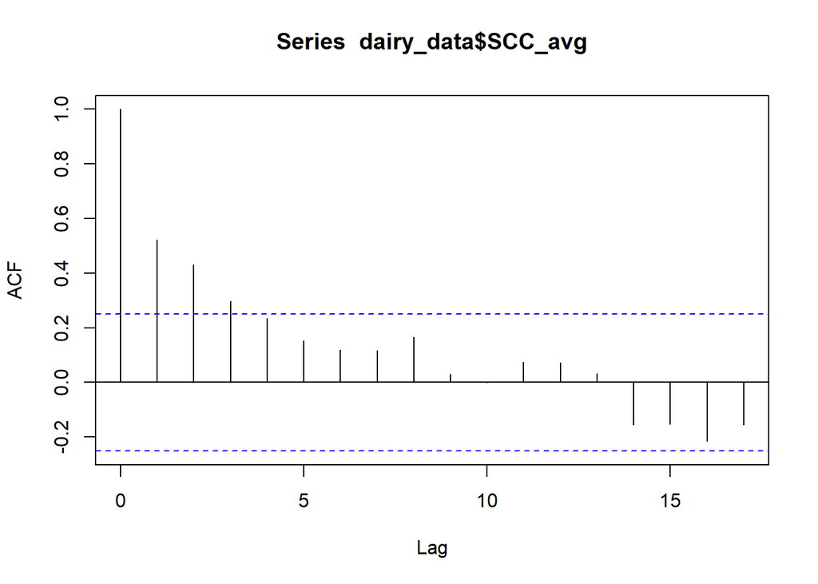

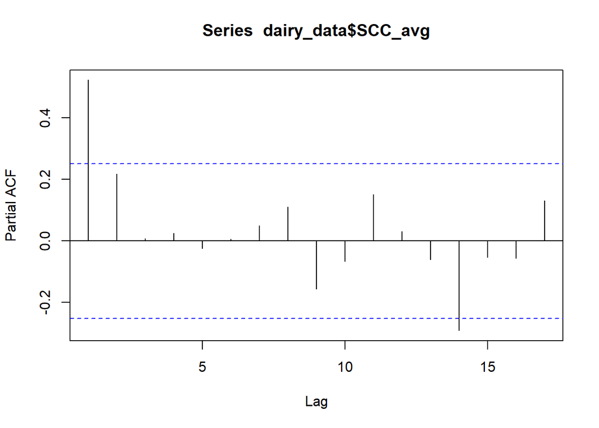

#### Temperature-Humidity Index

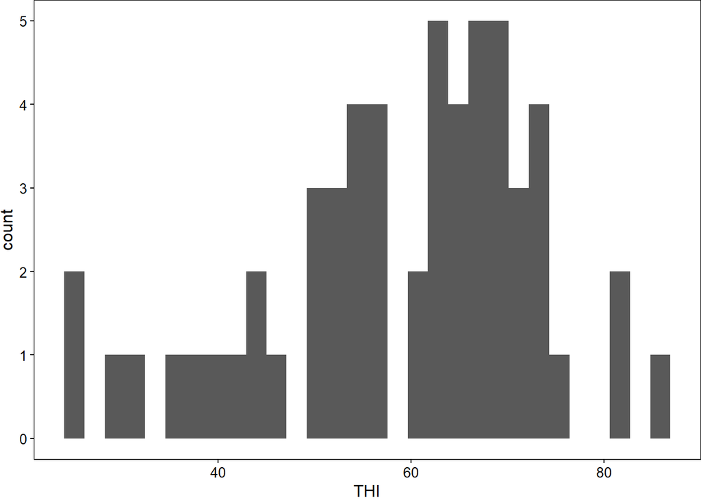

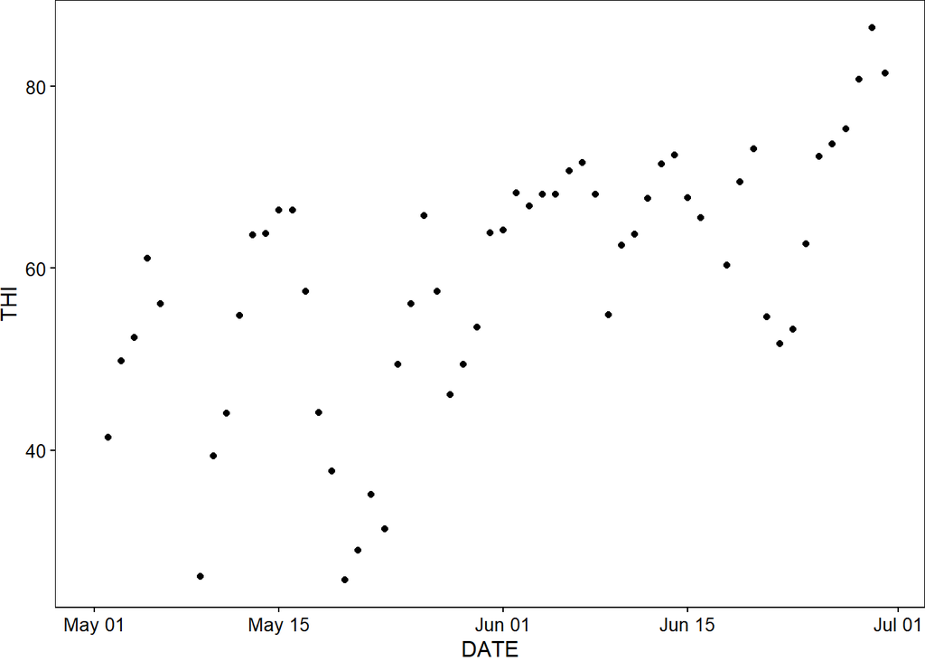

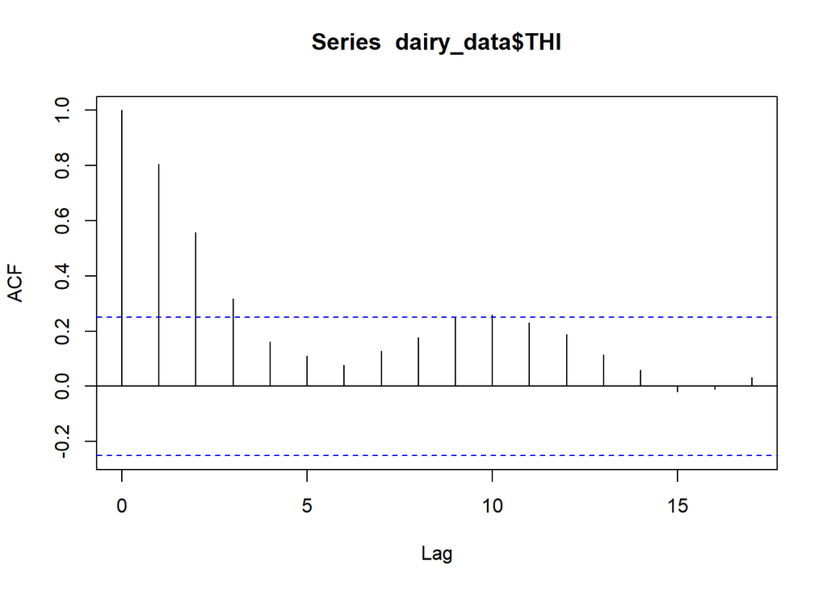

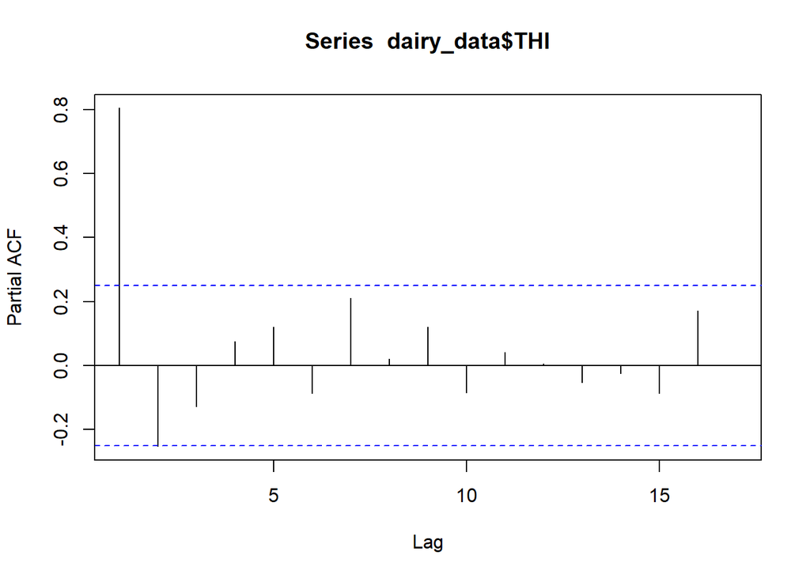

#### Ozone (ppb)

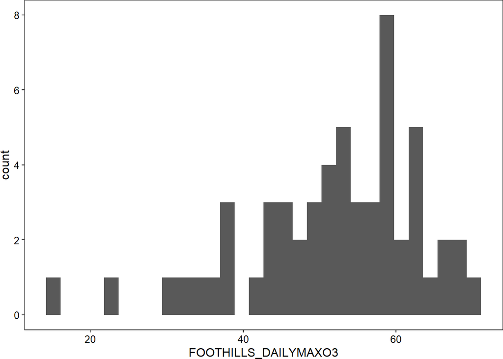

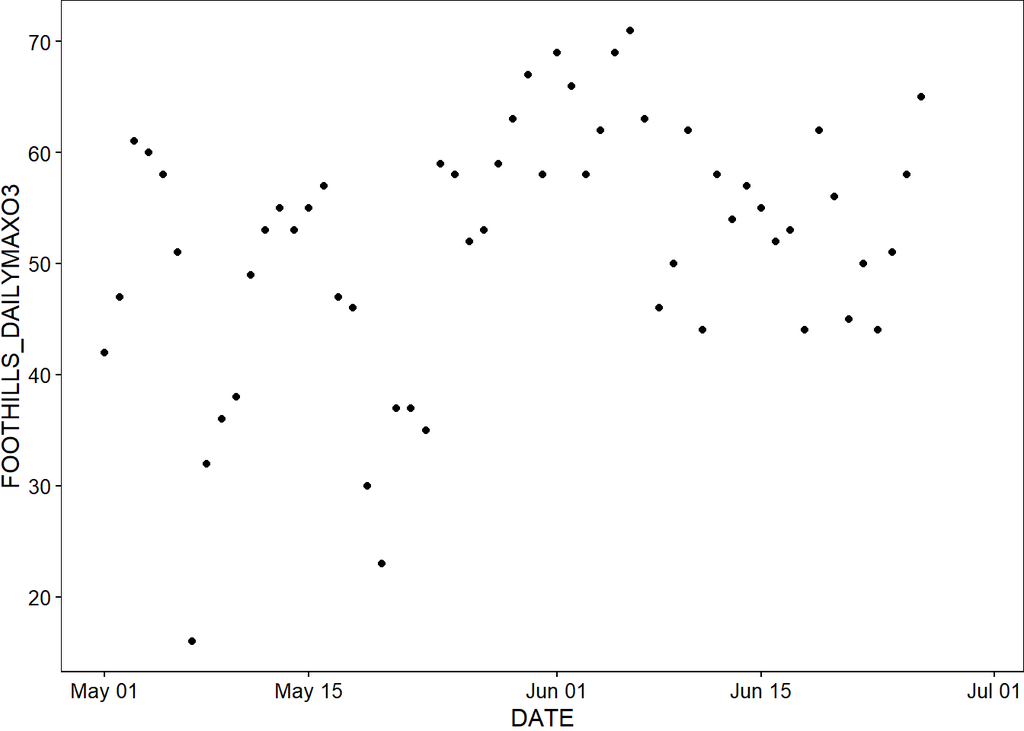

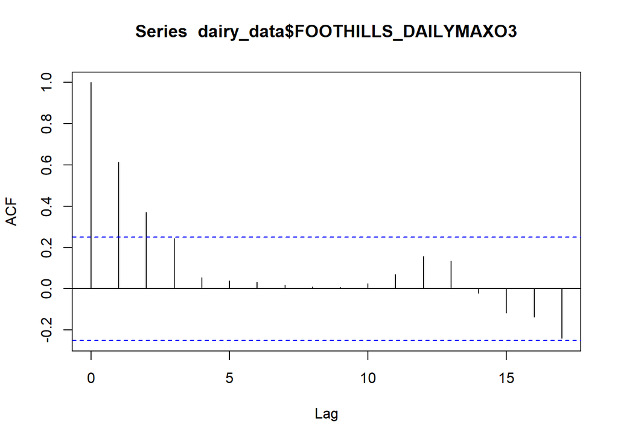

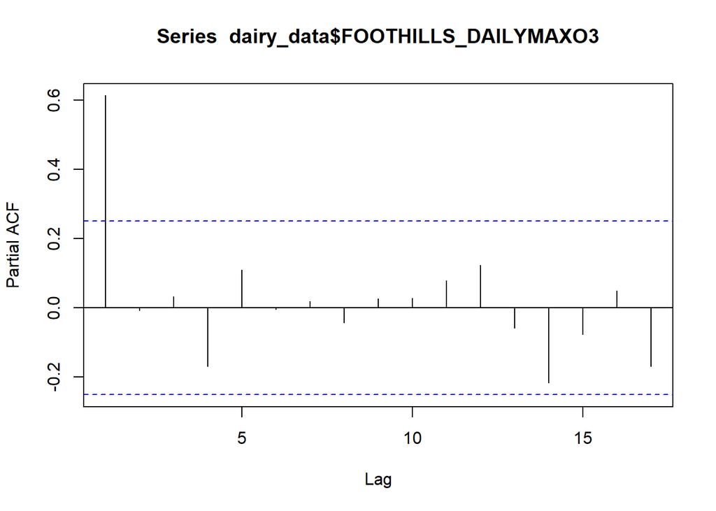

#### Daily mean PM2.5 (ug/m3)

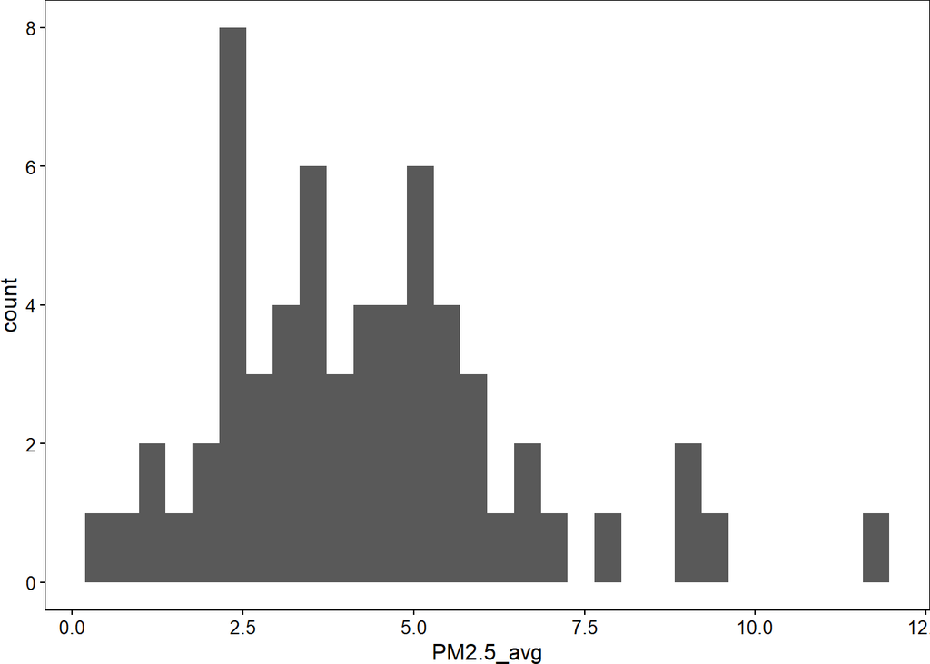

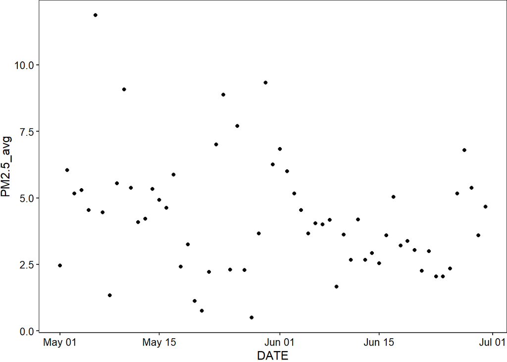

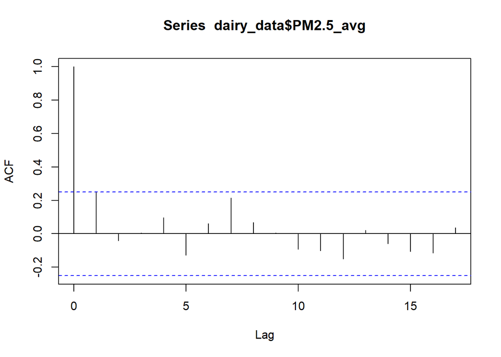

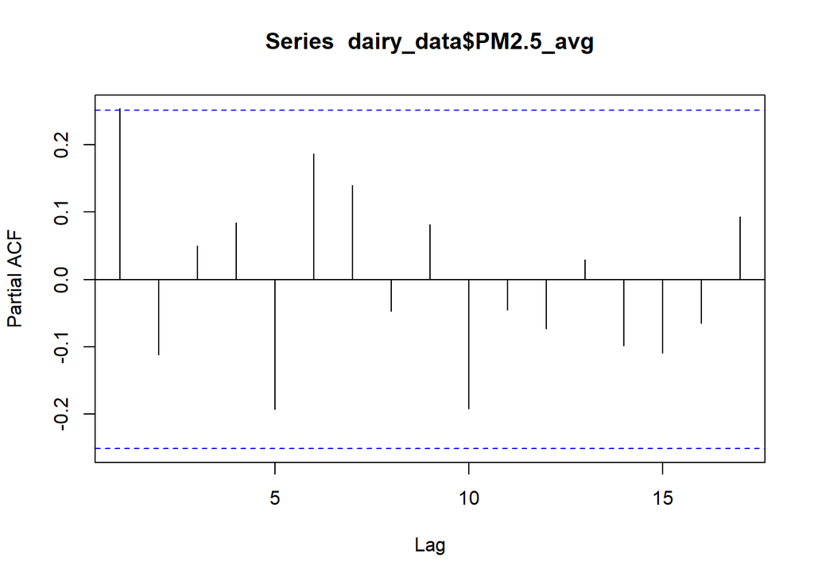

#### Daily maximum PM2.5 (ug/m3)

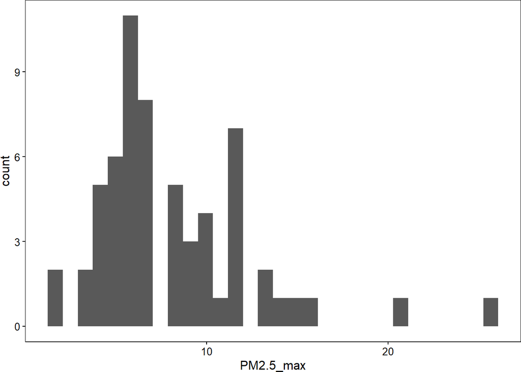

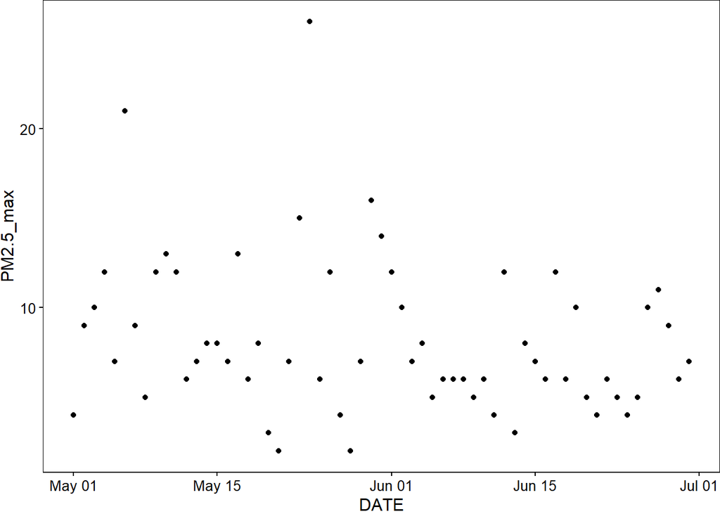

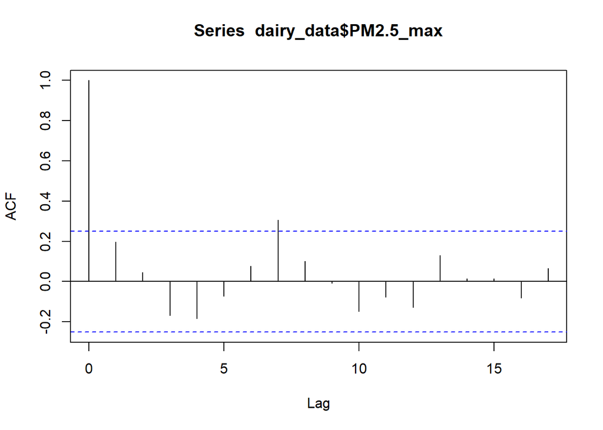

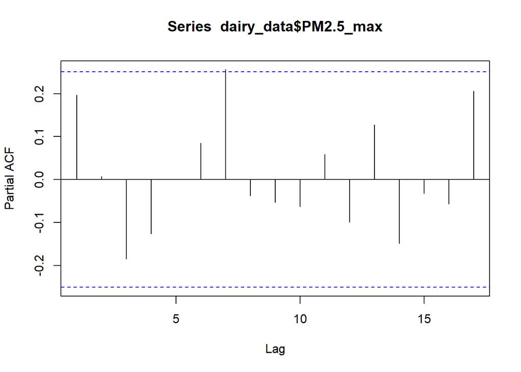

#### Correlations between each outcome and the predictor variables

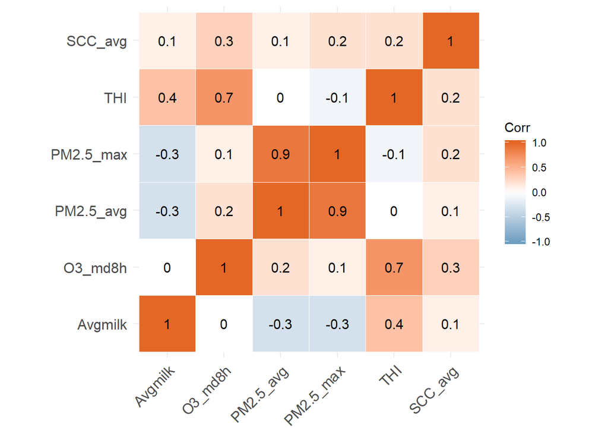

## Regression Analyses for Daily Production

We used two different modeling approaches to estimate the relationship between daily milk production and the environmental predictors: linear regression and generalized least squares with an autrocorrelation (AR1) structure.

#### Linear regression results

Model 0: Just date

```
##
## Call:
## lm(formula = Avgmilk ~ DATE, data = dairy_data)
##
## Residuals:
##     Min      1Q  Median      3Q     Max
## -4.9457 -0.8252  0.4439  1.3619  2.4518
##
## Coefficients:
##                Estimate  Std. Error t value   Pr(>|t|)
## (Intercept) -1068.56415   230.36910  -4.638 0.00001996 ***
## DATE            0.06411     0.01276   5.022 0.00000502 ***
## ---
## Signif. codes:  0 '***' 0.001 '**' 0.01 '*' 0.05 '.' 0.1 ' ' 1
##
## Residual standard error: 1.755 on 59 degrees of freedom
## Multiple R-squared:  0.2995, Adjusted R-squared:  0.2876
## F-statistic: 25.22 on 1 and 59 DF,  p-value: 0.000005024
```

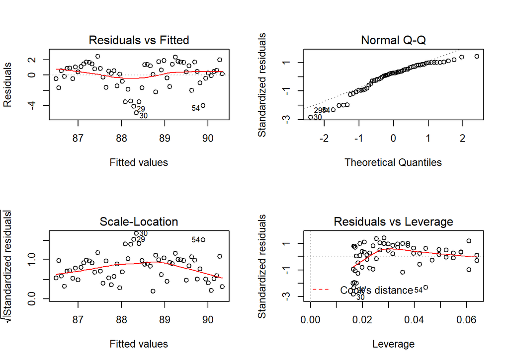

Model 1: Add THI

```
##
## Call:
## lm(formula = Avgmilk ~ THI, data = dairy_data)
##
## Residuals:
##     Min      1Q  Median      3Q     Max
## -4.6459 -1.0441  0.3745  1.3042  2.7478
##
## Coefficients:
##             Estimate Std. Error t value             Pr(>|t|)
## (Intercept) 83.81056    1.04398  80.280 < 0.0000000000000002 ***
## THI          0.07914    0.01727   4.583            0.0000268 ***
## ---
## Signif. codes:  0 '***' 0.001 '**' 0.01 '*' 0.05 '.' 0.1 ' ' 1
##
## Residual standard error: 1.803 on 55 degrees of freedom
##   (4 observations deleted due to missingness)
## Multiple R-squared:  0.2764, Adjusted R-squared:  0.2632
## F-statistic: 21.01 on 1 and 55 DF,  p-value: 0.00002677
```

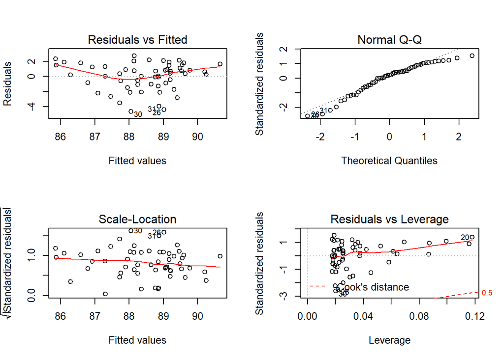

Model 2: Add ozone

```
##
## Call:
## lm(formula = Avgmilk ~ THI + FOOTHILLS_DAILYMAXO3, data = dairy_data)
##
## Residuals:
##     Min      1Q  Median      3Q     Max
## -4.9809 -1.0308  0.5761  1.2443  2.5870
##
## Coefficients:
##                      Estimate Std. Error t value             Pr(>|t|)
## (Intercept)          86.77965    1.21974  71.146 < 0.0000000000000002 ***
## THI                   0.13835    0.02520   5.490           0.00000134 ***
## FOOTHILLS_DAILYMAXO3 -0.12114    0.03182  -3.807             0.000386 ***
## ---
## Signif. codes:  0 '***' 0.001 '**' 0.01 '*' 0.05 '.' 0.1 ' ' 1
##
## Residual standard error: 1.642 on 50 degrees of freedom
##   (8 observations deleted due to missingness)
## Multiple R-squared:  0.3763, Adjusted R-squared:  0.3514
## F-statistic: 15.09 on 2 and 50 DF,  p-value: 0.000007477
```

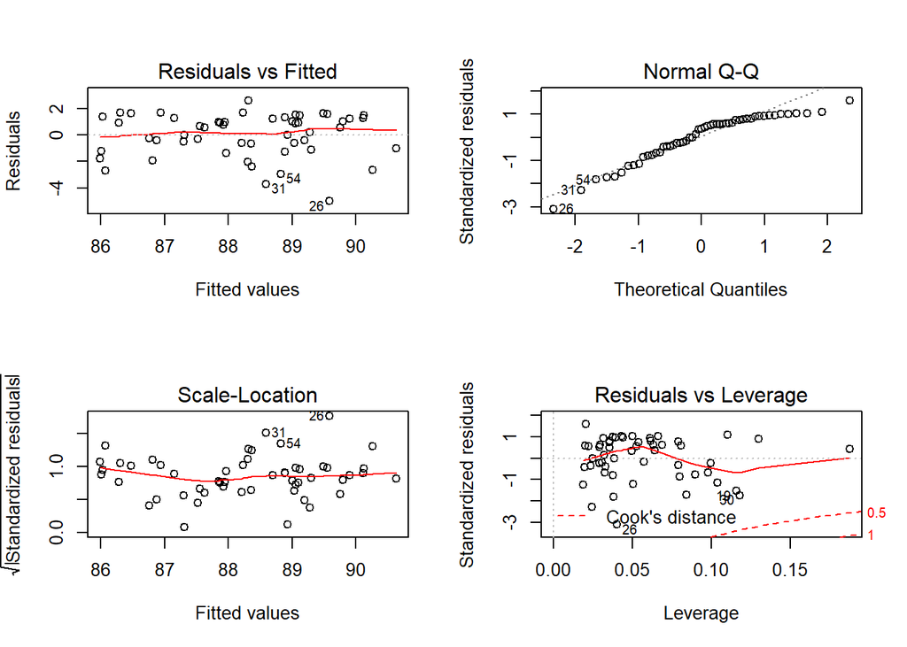

Model 3: Add daily mean PM2.5

```
##
## Call:
## lm(formula = Avgmilk ~ THI + FOOTHILLS_DAILYMAXO3 + PM2.5_avg,
##     data = dairy_data)
##
## Residuals:
##     Min      1Q  Median      3Q     Max
## -4.3370 -0.8704  0.5785  1.1496  2.2333
##
## Coefficients:
##                      Estimate Std. Error t value             Pr(>|t|)
## (Intercept)          87.20308    1.22876  70.969 < 0.0000000000000002 ***
## THI                   0.13045    0.02528   5.160           0.00000446 ***
## FOOTHILLS_DAILYMAXO3 -0.10715    0.03249  -3.297              0.00182 **
## PM2.5_avg            -0.16543    0.10232  -1.617              0.11237
## ---
## Signif. codes:  0 '***' 0.001 '**' 0.01 '*' 0.05 '.' 0.1 ' ' 1
##
## Residual standard error: 1.617 on 49 degrees of freedom
##   (8 observations deleted due to missingness)
## Multiple R-squared:  0.4079, Adjusted R-squared:  0.3717
## F-statistic: 11.25 on 3 and 49 DF,  p-value: 0.000009865
```

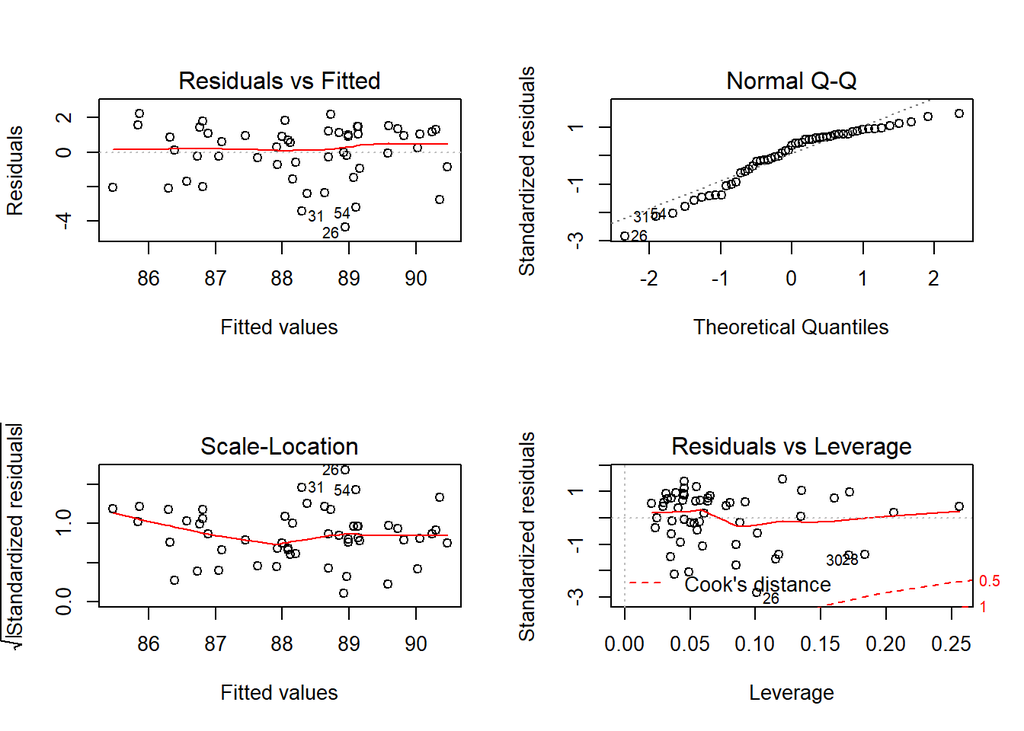

Model 4: Swap for daily max pm2.5

```
##
## Call:
## lm(formula = Avgmilk ~ THI + FOOTHILLS_DAILYMAXO3 + PM2.5_max,
##     data = dairy_data)
##
## Residuals:
##     Min      1Q  Median      3Q     Max
## -4.7313 -1.0001  0.4484  1.1868  2.4389
##
## Coefficients:
##                      Estimate Std. Error t value             Pr(>|t|)
## (Intercept)          87.10613    1.27280  68.436 < 0.0000000000000002 ***
## THI                   0.13124    0.02641   4.969           0.00000862 ***
## FOOTHILLS_DAILYMAXO3 -0.11207    0.03338  -3.357              0.00153 **
## PM2.5_max            -0.04831    0.05281  -0.915              0.36483
## ---
## Signif. codes:  0 '***' 0.001 '**' 0.01 '*' 0.05 '.' 0.1 ' ' 1
##
## Residual standard error: 1.645 on 49 degrees of freedom
##   (8 observations deleted due to missingness)
## Multiple R-squared:  0.3868, Adjusted R-squared:  0.3493
## F-statistic:  10.3 on 3 and 49 DF,  p-value: 0.00002272
```

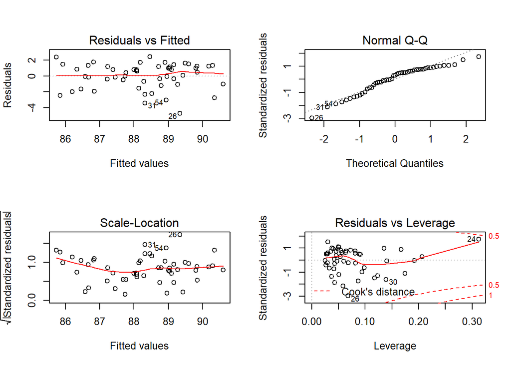

#### Generalized least squares regression results

Using a complete dataset:

```
## [1] 53
```

```
##       DATE               Avgmilk      FOOTHILLS_DAILYMAXO3
##  Min.   :2019-05-02   Min.   :83.40   Min.   :23.00
##  1st Qu.:2019-05-17   1st Qu.:87.20   1st Qu.:47.00
##  Median :2019-05-30   Median :88.40   Median :55.00
##  Mean   :2019-05-29   Mean   :88.27   Mean   :52.98
##  3rd Qu.:2019-06-12   3rd Qu.:89.90   3rd Qu.:59.00
##  Max.   :2019-06-26   Max.   :91.60   Max.   :71.00
##    PM2.5_avg        PM2.5_max           THI           SCC_avg
##  Min.   : 0.500   Min.   : 2.000   Min.   :25.77   Min.   : 72.00
##  1st Qu.: 2.667   1st Qu.: 6.000   1st Qu.:49.85   1st Qu.: 83.50
##  Median : 4.043   Median : 7.000   Median :61.08   Median : 88.00
##  Mean   : 4.309   Mean   : 8.283   Mean   :57.19   Mean   : 88.99
##  3rd Qu.: 5.333   3rd Qu.:10.000   3rd Qu.:67.65   3rd Qu.: 96.00
##  Max.   :11.875   Max.   :26.000   Max.   :73.63   Max.   :110.00
```

Model 0: Just date

```
## Generalized least squares fit by REML
##   Model: Avgmilk ~ DATE
##   Data: dairy_data2
##        AIC     BIC    logLik
##   205.6167 213.344 -98.80833
##
## Correlation Structure: AR(1)
##  Formula: ~1
##  Parameter estimate(s):
##       Phi
## 0.6295455
##
## Coefficients:
##                  Value Std.Error   t-value p-value
## (Intercept) -1035.7465  581.8829 -1.779991   0.081
## DATE            0.0623    0.0322  1.931610   0.059
##
##  Correlation:
##      (Intr)
## DATE -1
##
## Standardized residuals:
##        Min         Q1        Med         Q3        Max
## -2.4692568 -0.6603945  0.3048394  0.7795790  1.3019352
##
## Residual standard error: 1.954813
## Degrees of freedom: 53 total; 51 residual
```

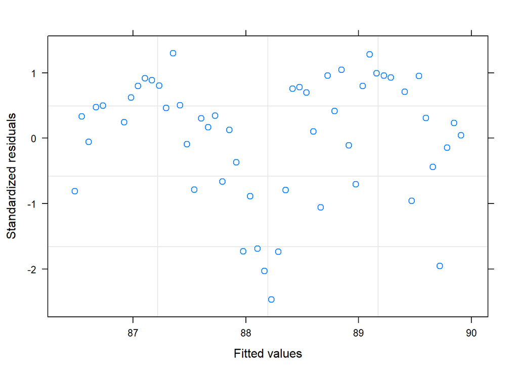

Model 1: Add THI

```
## Generalized least squares fit by REML
##   Model: Avgmilk ~ DATE + THI
##   Data: dairy_data2
##        AIC      BIC    logLik
##   211.1318 220.6919 -100.5659
##
## Correlation Structure: AR(1)
##  Formula: ~1
##  Parameter estimate(s):
##       Phi
## 0.6113721
##
## Coefficients:
##                 Value Std.Error   t-value p-value
## (Intercept) -741.7825  589.5637 -1.258189  0.2142
## DATE           0.0459    0.0327  1.403032  0.1668
## THI            0.0367    0.0262  1.400320  0.1676
##
##  Correlation:
##      (Intr) DATE
## DATE -1.000
## THI   0.348 -0.350
##
## Standardized residuals:
##        Min         Q1        Med         Q3        Max
## -2.4714922 -0.4003497  0.2522842  0.7322124  1.2097599
##
## Residual standard error: 1.899327
## Degrees of freedom: 53 total; 50 residual
```

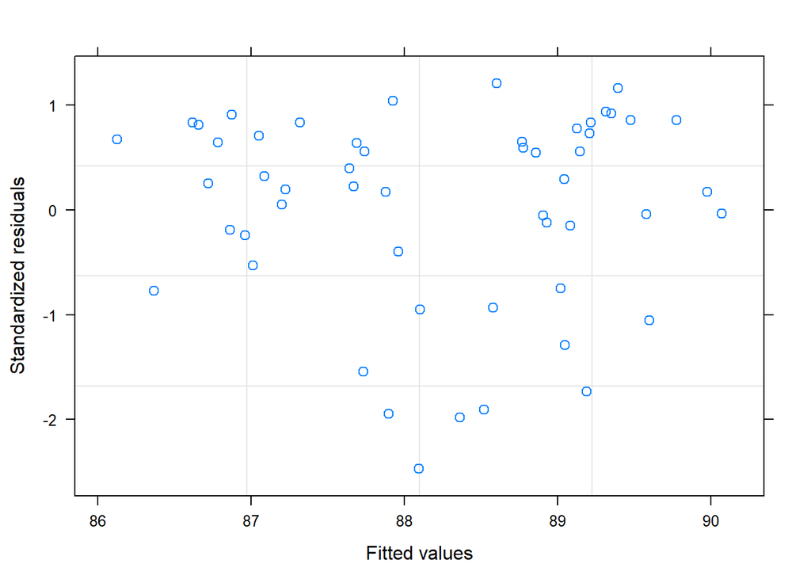

Model 2: Add ozone

```
## Generalized least squares fit by REML
##   Model: Avgmilk ~ DATE + THI + FOOTHILLS_DAILYMAXO3
##   Data: dairy_data2
##        AIC      BIC    logLik
##   218.0518 229.4027 -103.0259
##
## Correlation Structure: AR(1)
##  Formula: ~1
##  Parameter estimate(s):
##       Phi
## 0.5848425
##
## Coefficients:
##                          Value Std.Error    t-value p-value
## (Intercept)          -706.3428  566.7881 -1.2462203  0.2186
## DATE                    0.0439    0.0314  1.3974409  0.1686
## THI                     0.0449    0.0318  1.4114409  0.1644
## FOOTHILLS_DAILYMAXO3   -0.0137    0.0319 -0.4295921  0.6694
##
##  Correlation:
##                      (Intr) DATE   THI
## DATE                 -1.000
## THI                   0.350 -0.352
## FOOTHILLS_DAILYMAXO3 -0.091  0.090 -0.566
##
## Standardized residuals:
##        Min         Q1        Med         Q3        Max
## -2.4007410 -0.3747236  0.2903414  0.7463361  1.2271963
##
## Residual standard error: 1.865352
## Degrees of freedom: 53 total; 49 residual
```